# Project I

Remco Bast

24-9-2020

# Project - Het voorspellen van zorgkosten

De dataset was verkregen van kaggle: https://www.kaggle.com/mirichoi0218/insurance en de data zou ook beschikbaar zijn bij het kopen van het boek Machine Learning With R van Brett Lantz.

Het doel van de dataset is om zo goed mogelijk de “charges”, ofwel de zorgkosten van individuen zo goed mogelijk te voorspelen. Het betreft een dataset met 1338 observaties en 7 variabelen.

## Inladen van libraries en de data

```r
#suppress om start up message te voorkomen
#suppressPackageStartupMessages({
  #library(tidyverse)
  #library(ggplot2)
  #library(corrplot)
  #library(scales)
#})

library(tidyverse)
library(ggplot2)
library(corrplot)
library(scales)
library(caret)
data <- read.csv("https://raw.githubusercontent.com/stedy/Machine-Learning-with-R-datasets/master/insurance.csv")
```

## Data exploratie

Nu de data is ingeladen laten we eens kijken naar wat voor variabelen we hebben en hoe deze eruit zien.

```r
head(data)
```

```
##   age    sex    bmi children smoker    region   charges
## 1  19 female 27.900        0    yes southwest 16884.924
## 2  18   male 33.770        1     no southeast  1725.552
## 3  28   male 33.000        3     no southeast  4449.462
## 4  33   male 22.705        0     no northwest 21984.471
## 5  32   male 28.880        0     no northwest  3866.855
## 6  31 female 25.740        0     no southeast  3756.622
```

We hebben dus informatie over de leeftijd, geslacht, aantal kinderen, bmi, rookstatus, de regio, en tot slot de uitkomst genaamd charges.

Laten we beginnen met het kijken naar descriptive statistics

```r
summary(data)
```

```
##       age            sex           bmi           children     smoker
##  Min.   :18.00   female:662   Min.   :15.96   Min.   :0.000   no :1064
##  1st Qu.:27.00   male  :676   1st Qu.:26.30   1st Qu.:0.000   yes: 274
##  Median :39.00                Median :30.40   Median :1.000
##  Mean   :39.21                Mean   :30.66   Mean   :1.095
##  3rd Qu.:51.00                3rd Qu.:34.69   3rd Qu.:2.000
##  Max.   :64.00                Max.   :53.13   Max.   :5.000
##        region       charges
##  northeast:324   Min.   : 1122
##  northwest:325   1st Qu.: 4740
##  southeast:364   Median : 9382
##  southwest:325   Mean   :13270
##                  3rd Qu.:16640
##                  Max.   :63770
```

We kunnen ook gelijk even kijken naar de correlaties tussen de numerieke variabelen:

```r
data %>%
  select_if(is.numeric) %>%
  cor()
```

```
##                age       bmi   children    charges
## age      1.0000000 0.1092719 0.04246900 0.29900819
## bmi      0.1092719 1.0000000 0.01275890 0.19834097
## children 0.0424690 0.0127589 1.00000000 0.06799823
## charges  0.2990082 0.1983410 0.06799823 1.00000000
```

Hierbij zien we dat er kleine correlaties zijn tussen leeftijd en zorgkosten (0.3) en bmi en zorgkosten (0.2).

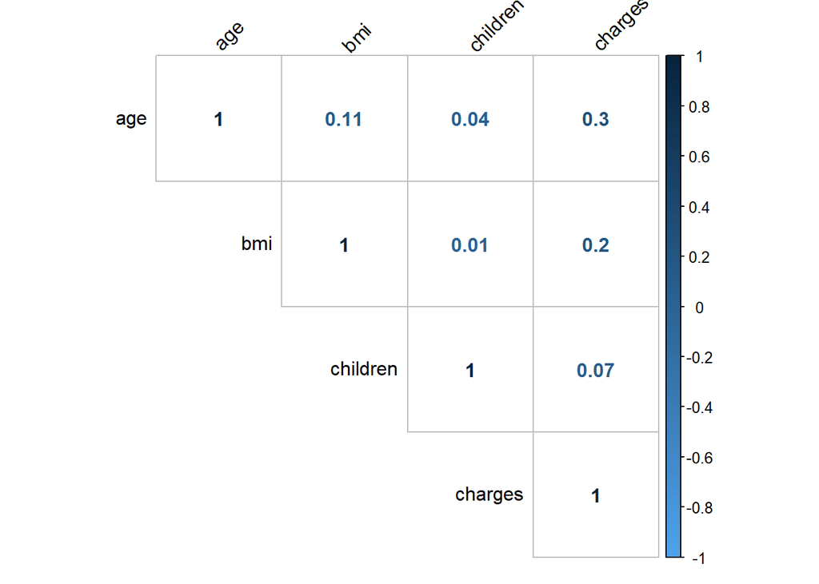

```r
col <- colorRampPalette(c("#50A3EB", "#06233D"))

data %>%
  select_if(is.numeric) %>%
  cor() %>%
  corrplot(method = "number", type = "upper", tl.col = "black", tl.srt = 45,
           col = col(200))
```

```r
# https://www.webfx.com/web-design/color-picker/06233D  -> kleuren hexcodes
# http://www.sthda.com/english/wiki/visualize-correlation-matrix-using-correlogram -> documentatie corrplot functie
```

Laten we nu eerst kijken naar de verdeling van de zorgkosten en vervolgens hoe de andere variabelen zich verhouden tot deze zorgkosten.

Visualisatie verdeling zorgkosten:

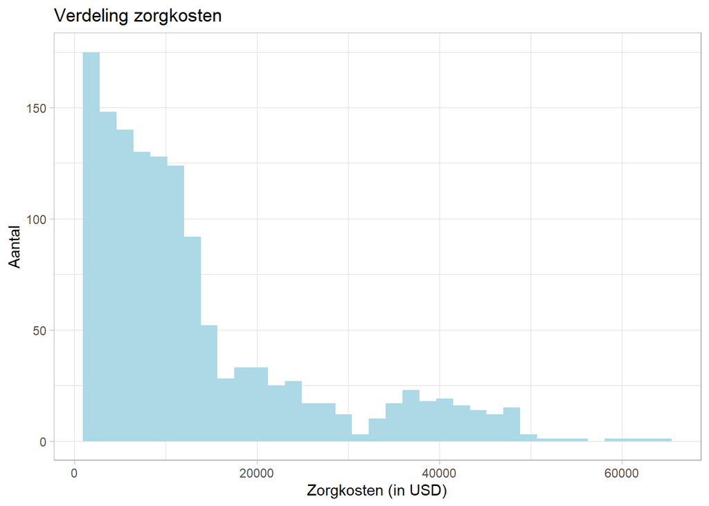

```r
ggplot(data = data, mapping = aes(x = charges)) +
  geom_histogram(bins = 35, fill = "lightblue") +
  labs(title = "Verdeling zorgkosten", y = "Aantal", x = "Zorgkosten (in USD)") +
  theme_light()
```

De meeste mensen hebben zorgkosten tussen de 1000 en +- 15000 USD. Een kleine groep mensen hebben zorgkosten van 20000-40000 USD en een enkeling heeft meer dan 50000 USD als zorgkosten.

Relatie tussen leeftijd en zorgkosten:

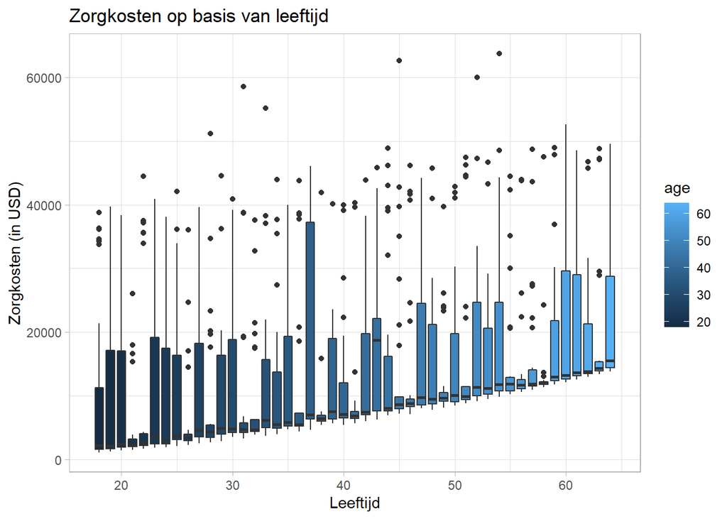

```r
ggplot(data = data, mapping = aes(x = age, y = charges)) +
  geom_boxplot(aes(group = age, fill = age)) +
  theme_light() +
  labs(title = "Zorgkosten op basis van leeftijd", x = "Leeftijd", y = "Zorgkosten (in USD)")
```

Er is een kleine relatie te zien tussen leeftijd en zorgkosten; naarmate de leeftijd toeneemt nemen ook de zorgkosten ook toe.

Zorgkosten voor mannen en vrouwen:

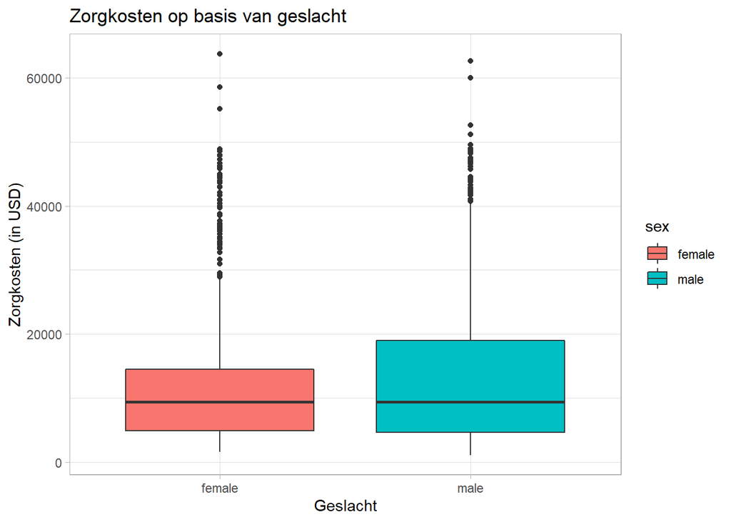

```r
ggplot(data = data, mapping = aes(x = sex, y = charges, fill = sex)) +
  geom_boxplot() +
  theme_light() +
  labs(title = "Zorgkosten op basis van geslacht", y = "Zorgkosten (in USD)", x = "Geslacht")
```

Er zit niet veel verschil tussen de zorgkosten van mannen en vrouwen in deze dataset.

Zorgkosten en roken:

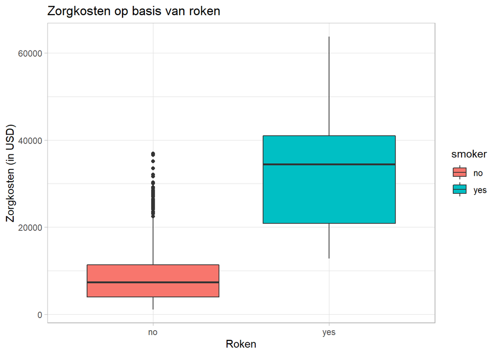

```r
ggplot(data = data, mapping = aes(x = smoker, y = charges, fill = smoker)) +
  geom_boxplot() +
  theme_light() +
  labs(title = "Zorgkosten op basis van roken", y = "Zorgkosten (in USD)", x = "Roken")
```

Wel zit er een groot verschil tussen de zorgkosten van rokers en niet-rokers. De mediane zorgkosten van rokers liggen ongeveer op de 35000 USD, terwijl die van niet-rokers maar rond de 8000 USD liggen.

Zorgkosten en regio:

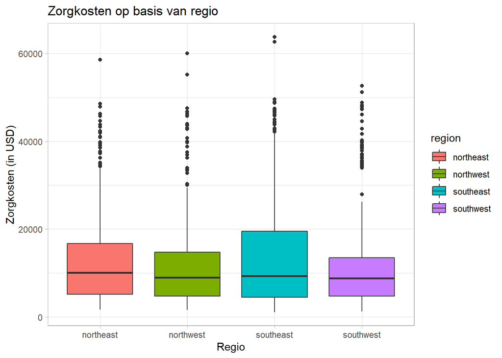

```r
ggplot(data = data, mapping = aes(x = region, y = charges, fill = region)) +
  geom_boxplot() +
  theme_light() +
  labs(title = "Zorgkosten op basis van regio", y = "Zorgkosten (in USD)", x = "Regio")
```

Het ziet er naar uit dat de mensen uit de regio Noord-oost meer zorgkosten hebben dan mensen uit andere regio’s. We kunnen dit ook numeriek bekijken door per regio te kijken naar de gemiddelde en mediane zorgkosten:

```r
data %>%
  group_by(region) %>%
  summarise(gemiddelde_zorgkosten = mean(charges), mediaan_zorgkosten = median(charges))
```

```
## # A tibble: 4 x 3
##   region    gemiddelde_zorgkosten mediaan_zorgkosten
##   <fct>                     <dbl>              <dbl>
## 1 northeast                13406.             10058.
## 2 northwest                12418.              8966.
## 3 southeast                14735.              9294.
## 4 southwest                12347.              8799.
```

Daaruit blijkt dat de mensen uit de regio Zuid-Oost gemiddeld gezien de meeste zorgkosten hebben (+- 1000 - 2000 USD meer). Als we dan kijken naar de mediane zorgkosten zien we dat deze in de regio Noord-Oost het hoogst zijn gevolgd door de regio Zuid-Oost. Over het algemeen kunnen we dus zeggen dat de mensen uit het Oosten meer zorgkosten hebben dan mensen uit het Westen.

Relatie tussen het aantal kinderen en zorgkosten:

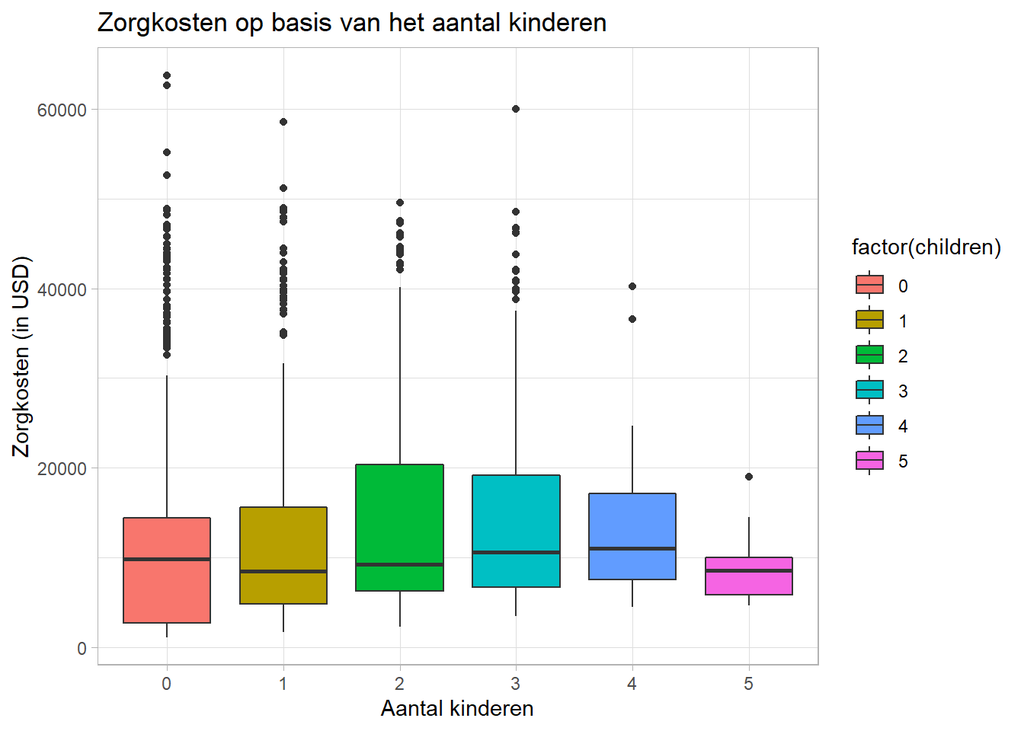

```r
ggplot(data = data, mapping = aes(x = factor(children), y = charges, fill = factor(children))) +
  geom_boxplot() +
  theme_light() +
  labs(title = "Zorgkosten op basis van het aantal kinderen", y = "Zorgkosten (in USD)", x = "Aantal kinderen")
```

Het lijkt alsof mensen met 0 kinderen hogere zorgkosten hebben, en verder lijkt het alsof de zorgkosten oplopen naarmate iemand meer kinderen heeft vanaf het eerste kind (afgezien van 5 kinderen). Aangezien er hier geen ordinaliteit is, veranderen we deze variabele naar een factor.

```r
data$children <- factor(data$children)
```

Relatie tussen BMI en zorgkosten:

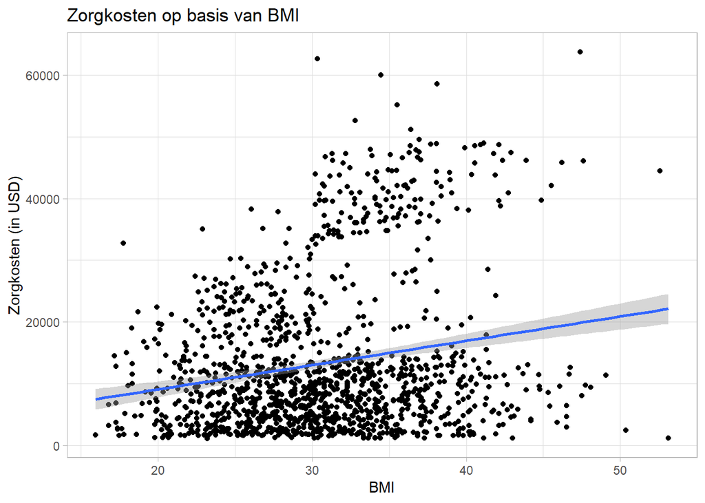

```r
ggplot(data = data, mapping = aes(x = bmi, y = charges)) +
  geom_point() +
  geom_smooth(method = "lm") +
  theme_light() +
  labs(title = "Zorgkosten op basis van BMI", y = "Zorgkosten (in USD)", x = "BMI")
```

Naarmate de BMI toeneemt, nemen ook de zorgkosten toe. Wellicht is dit nog anders voor rokers en niet-rokers, dus laten we dit ook visualiseren:

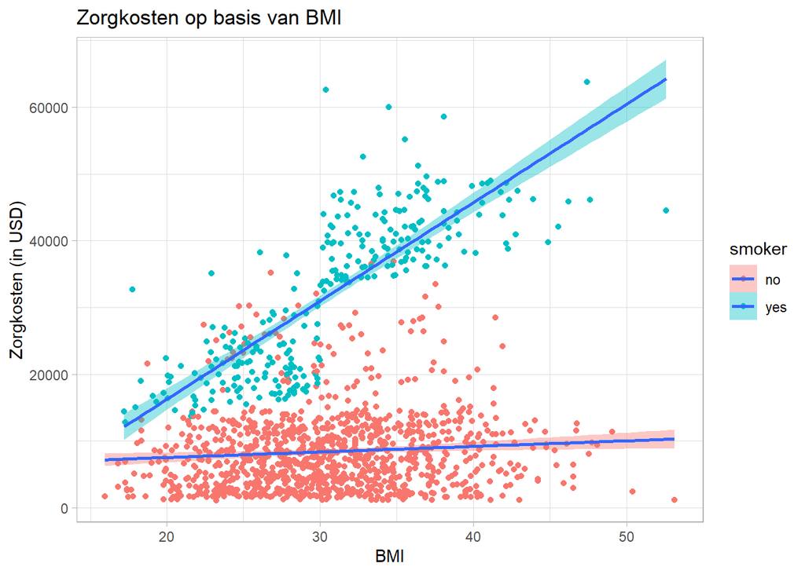

```r
ggplot(data = data, mapping = aes(x = bmi, y = charges, fill = smoker)) +
  geom_point(aes(color = smoker)) +
  geom_smooth(method = "lm") +
  theme_light() +
  labs(title = "Zorgkosten op basis van BMI", y = "Zorgkosten (in USD)", x = "BMI")
```

We zien hierbij overduidelijk dat de relatie tussen BMI en zorgkosten voornamelijk toeneemt voor rokers.

Voor nu hebben we BMI continue gelaten, maar we kunnen deze BMI variabele ook veranderen naar een binaire variabele om aan te geven of iemand obesitas heeft (BMI > 30) of niet.

```r
data <- data %>%
  mutate(obesitas = bmi > 30)
```

Als we dan kijken naar de eerste paar observaties dan zien we dat we een nieuwe kolom hebben gemaakt genaamd obesitas en dat deze TRUE is als de BMI boven de 30 is en FALSE is als de BMI onder de 30 is.

```r
head(data)
```

```
##   age    sex    bmi children smoker    region   charges obesitas
## 1  19 female 27.900        0    yes southwest 16884.924    FALSE
## 2  18   male 33.770        1     no southeast  1725.552     TRUE
## 3  28   male 33.000        3     no southeast  4449.462     TRUE
## 4  33   male 22.705        0     no northwest 21984.471    FALSE
## 5  32   male 28.880        0     no northwest  3866.855    FALSE
## 6  31 female 25.740        0     no southeast  3756.622    FALSE
```

Deze nieuwe kolom is nu een logical data type, maar als we deze willen meenemen in onze statistische analyses moeten we deze veranderen naar een factor variabele.

```r
data$obesitas <- factor(data$obesitas)
```

Laten we kijken of de zorgkosten verschillen tussen mensen met en zonder obesitas.

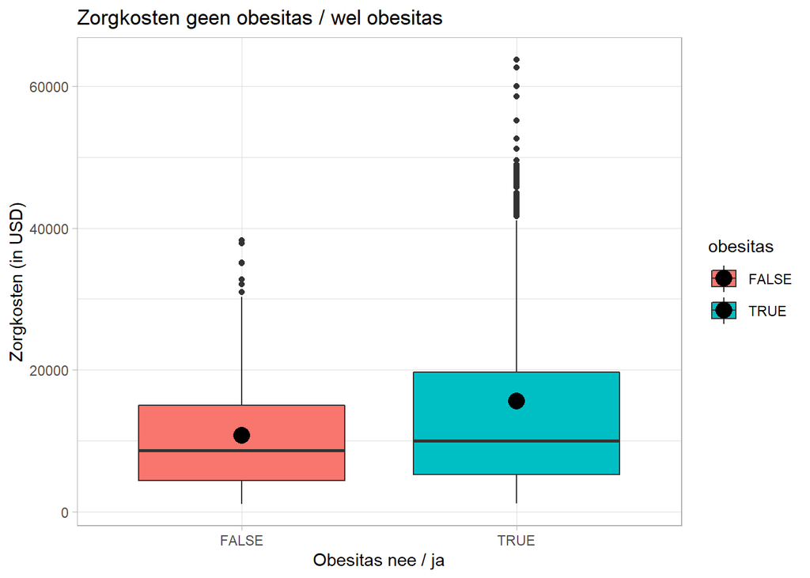

```r
ggplot(data = data, mapping = aes(x = obesitas, y = charges, fill = obesitas)) +
  geom_boxplot() +
  stat_summary(fun=mean, geom="point", shape=20, size=7, color="black") +
  labs(title = "Zorgkosten geen obesitas / wel obesitas", x = "Obesitas nee / ja", y = "Zorgkosten (in USD)") +
  theme_light()
```

Hierbij zien we dat de mediane zorgkosten niet veel van elkaar verschillen of mensen wel of geen obesitas hebben. Echter, als we dan naar de gemiddelde zorgkosten kijken (aangegeven met de zwarte cirkel) dan zien we dat de mensen die wel obesitas hebben +- 5000 USD meer hebben aan zorgkosten.

Als we exact willen weten hoeveel verschil er zit tussen de gemiddelde zorgkosten van mensen en zonder obesitas dan kunnen we dit ook weer numeriek bekijken:

```r
data %>%
  group_by(obesitas) %>%
  summarise(gemiddelde_zorgkosten = mean(charges))
```

```
## # A tibble: 2 x 2
##   obesitas gemiddelde_zorgkosten
##   <fct>                    <dbl>
## 1 FALSE                   10719.
## 2 TRUE                    15561.
```

## Data opsplitsen in een training-set en test-set

```r
set.seed(101)

trainIndex <- createDataPartition(data$charges, p = .8,
                                  list = FALSE,
                                  times = 1)

train <- data[trainIndex, ]
test <- data[-trainIndex, ]
```

```r
linregressie <- lm(charges ~ age + sex + children + region + obesitas + smoker, data = train)
summary(linregressie)
```

```
##
## Call:
## lm(formula = charges ~ age + sex + children + region + obesitas +
##     smoker, data = train)
##
## Residuals:
##      Min       1Q   Median       3Q      Max
## -13471.9  -3489.3   -300.2   1334.7  27652.2
##
## Coefficients:
##                 Estimate Std. Error t value Pr(>|t|)
## (Intercept)     -4154.42     714.79  -5.812 8.16e-09 ***
## age               261.68      13.46  19.443  < 2e-16 ***
## sexmale            48.89     378.25   0.129  0.89719
## children1         388.63     479.92   0.810  0.41825
## children2        1550.83     528.43   2.935  0.00341 **
## children3         934.91     628.58   1.487  0.13722
## children4        3855.59    1345.02   2.867  0.00423 **
## children5        1097.36    1527.53   0.718  0.47268
## regionnorthwest  -494.26     546.91  -0.904  0.36635
## regionsoutheast  -549.33     529.14  -1.038  0.29944
## regionsouthwest  -702.06     537.31  -1.307  0.19163
## obesitasTRUE     4092.49     385.84  10.607  < 2e-16 ***
## smokeryes       23727.52     471.45  50.329  < 2e-16 ***
## ---
## Signif. codes:  0 '***' 0.001 '**' 0.01 '*' 0.05 '.' 0.1 ' ' 1
##
## Residual standard error: 6156 on 1059 degrees of freedom
## Multiple R-squared:  0.7468, Adjusted R-squared:  0.7439
## F-statistic: 260.3 on 12 and 1059 DF,  p-value: < 2.2e-16
```

Geslacht lijkt geen verschil te maken in de lineaire regressie (P = > 0.05). Deze kunnen we dus verwijderen.

```r
linregressie2 <- lm(charges ~ age + children + region + obesitas + smoker, data = train)
summary(linregressie2)
```

```
##
## Call:
## lm(formula = charges ~ age + children + region + obesitas + smoker,
##     data = train)
##
## Residuals:
##      Min       1Q   Median       3Q      Max
## -13498.2  -3493.4   -272.8   1319.6  27672.2
##
## Coefficients:
##                 Estimate Std. Error t value Pr(>|t|)
## (Intercept)     -4130.34     689.76  -5.988  2.9e-09 ***
## age               261.61      13.44  19.462  < 2e-16 ***
## children1         390.21     479.54   0.814  0.41598
## children2        1550.05     528.15   2.935  0.00341 **
## children3         936.77     628.12   1.491  0.13616
## children4        3858.30    1344.23   2.870  0.00418 **
## children5        1102.01    1526.39   0.722  0.47047
## regionnorthwest  -493.65     546.64  -0.903  0.36669
## regionsoutheast  -547.69     528.75  -1.036  0.30052
## regionsouthwest  -699.98     536.82  -1.304  0.19254
## obesitasTRUE     4094.00     385.48  10.620  < 2e-16 ***
## smokeryes       23732.24     469.82  50.514  < 2e-16 ***
## ---
## Signif. codes:  0 '***' 0.001 '**' 0.01 '*' 0.05 '.' 0.1 ' ' 1
##
## Residual standard error: 6153 on 1060 degrees of freedom
## Multiple R-squared:  0.7468, Adjusted R-squared:  0.7441
## F-statistic: 284.2 on 11 and 1060 DF,  p-value: < 2.2e-16
```

Verder zijn de regiocoëfficienten ook niet significant, dus deze kunnen we er ook uit halen.

```r
linregressie3 <- lm(charges ~ age + children + obesitas + smoker, data = train)
summary(linregressie3)
```

```
##
## Call:
## lm(formula = charges ~ age + children + obesitas + smoker, data = train)
##
## Residuals:
##    Min     1Q Median     3Q    Max
## -13338  -3515   -286   1389  27562
##
## Coefficients:
##              Estimate Std. Error t value Pr(>|t|)
## (Intercept)  -4533.09     616.50  -7.353 3.87e-13 ***
## age            261.43      13.43  19.466  < 2e-16 ***
## children1      388.41     479.06   0.811  0.41767
## children2     1531.12     527.25   2.904  0.00376 **
## children3      933.75     627.31   1.489  0.13692
## children4     3834.11    1343.24   2.854  0.00440 **
## children5     1011.15    1521.36   0.665  0.50643
## obesitasTRUE  4042.77     378.20  10.690  < 2e-16 ***
## smokeryes    23757.00     467.23  50.847  < 2e-16 ***
## ---
## Signif. codes:  0 '***' 0.001 '**' 0.01 '*' 0.05 '.' 0.1 ' ' 1
##
## Residual standard error: 6150 on 1063 degrees of freedom
## Multiple R-squared:  0.7463, Adjusted R-squared:  0.7444
## F-statistic: 390.9 on 8 and 1063 DF,  p-value: < 2.2e-16
```

```r
head(test)
```

```
##    age    sex    bmi children smoker    region   charges obesitas
## 4   33   male 22.705        0     no northwest 21984.471    FALSE
## 7   46 female 33.440        1     no southeast  8240.590     TRUE
## 9   37   male 29.830        2     no northeast  6406.411    FALSE
## 24  34 female 31.920        1    yes northeast 37701.877     TRUE
## 28  55 female 32.775        2     no northwest 12268.632     TRUE
## 34  63   male 28.310        0     no northwest 13770.098    FALSE
```

```r
trainoptie <- trainControl(method = "repeatedcv", number = 10, repeats = 5)
```

```r
set.seed(1)
linregressie.fit <- train(charges ~ age + children + obesitas + smoker,
                          data = train,
                          method = "lm",
                          trControl = trainoptie)

linregressie.fit
```

```
## Linear Regression
##
## 1072 samples
##    4 predictor
##
## No pre-processing
## Resampling: Cross-Validated (10 fold, repeated 5 times)
## Summary of sample sizes: 965, 965, 964, 965, 964, 966, ...
## Resampling results:
##
##   RMSE      Rsquared   MAE
##   6157.081  0.7458328  4296.384
##
## Tuning parameter 'intercept' was held constant at a value of TRUE
```

```r
set.seed(1)
randomforest.fit <- train(charges ~ age + sex + children + region + obesitas + smoker,
                          data = train,
                          method = "rf", # random forest
                          trControl = trainoptie,
                          tuneGrid = expand.grid(mtry = c(1,2,3,4,5)), #mtry is hoeveel variabelen er geselecteerd worden voor de trees.
                          importance = TRUE)

randomforest.fit
```

```
## Random Forest
##
## 1072 samples
##    6 predictor
##
## No pre-processing
## Resampling: Cross-Validated (10 fold, repeated 5 times)
## Summary of sample sizes: 965, 965, 964, 965, 964, 966, ...
## Resampling results across tuning parameters:
##
##   mtry  RMSE      Rsquared   MAE
##   1     9249.735  0.7829673  6867.292
##   2     6243.993  0.8286080  4503.201
##   3     5076.663  0.8410895  3290.231
##   4     4821.116  0.8420651  2848.597
##   5     4803.838  0.8403888  2726.072
##
## RMSE was used to select the optimal model using the smallest value.
## The final value used for the model was mtry = 5.
```

```r
varImp(randomforest.fit)
```

```
## rf variable importance
##
##                   Overall
## smokeryes       100.00000
## obesitasTRUE     52.58840
## age              48.10523
## children1         3.22273
## children3         2.54490
## children2         2.50372
## children5         2.44161
## regionsouthwest   1.52388
## regionnorthwest   1.51526
## children4         0.86134
## sexmale           0.02191
## regionsoutheast   0.00000
```

```r
set.seed(1)
knn.fit <- train(charges ~ age + sex + children + region + obesitas + smoker,
                 data = train,
                 preProcess = c("center", "scale"),
                 method = "knn", #knn
                 trControl = trainoptie)

knn.fit
```

```
## k-Nearest Neighbors
##
## 1072 samples
##    6 predictor
##
## Pre-processing: centered (12), scaled (12)
## Resampling: Cross-Validated (10 fold, repeated 5 times)
## Summary of sample sizes: 965, 965, 964, 965, 964, 966, ...
## Resampling results across tuning parameters:
##
##   k  RMSE      Rsquared   MAE
##   5  5898.635  0.7634104  3724.707
##   7  5950.190  0.7604255  3803.585
##   9  6114.052  0.7502574  3919.969
##
## RMSE was used to select the optimal model using the smallest value.
## The final value used for the model was k = 5.
```

```r
varImp(knn.fit)
```

```
## loess r-squared variable importance
##
##           Overall
## smoker   100.0000
## age       15.5782
## obesitas   5.8999
## children   0.6541
## sex        0.4921
## region     0.0000
```

```r
set.seed(1)
lasso.fit <- train(charges ~ age + sex + children + region + obesitas + smoker,
                   data = train,
                   method = "glmnet",
                   tuneGrid = expand.grid(
                     .alpha = 1,
                     .lambda = seq(50, 100, by = 1)),
                   trControl = trainoptie)

lasso.fit
```

```
## glmnet
##
## 1072 samples
##    6 predictor
##
## No pre-processing
## Resampling: Cross-Validated (10 fold, repeated 5 times)
## Summary of sample sizes: 965, 965, 964, 965, 964, 966, ...
## Resampling results across tuning parameters:
##
##   lambda  RMSE      Rsquared   MAE
##    50     6170.475  0.7447427  4281.713
##    51     6170.412  0.7447490  4281.265
##    52     6170.345  0.7447556  4280.813
##    53     6170.252  0.7447643  4280.345
```

[output cut: 51 more lines]

```r
varImp(lasso.fit)
```

```
## glmnet variable importance
##
##                 Overall
## smokeryes       100.000
## obesitasTRUE     16.444
## children4        12.102
## children2         4.485
## children3         1.782
## age               1.088
## regionsouthwest   0.475
## sexmale           0.000
## regionnorthwest   0.000
## regionsoutheast   0.000
## children5         0.000
## children1         0.000
```

```r
resultaat <- resamples(list(knn = knn.fit, lasso = lasso.fit, rf = randomforest.fit, lm = linregressie.fit))
```

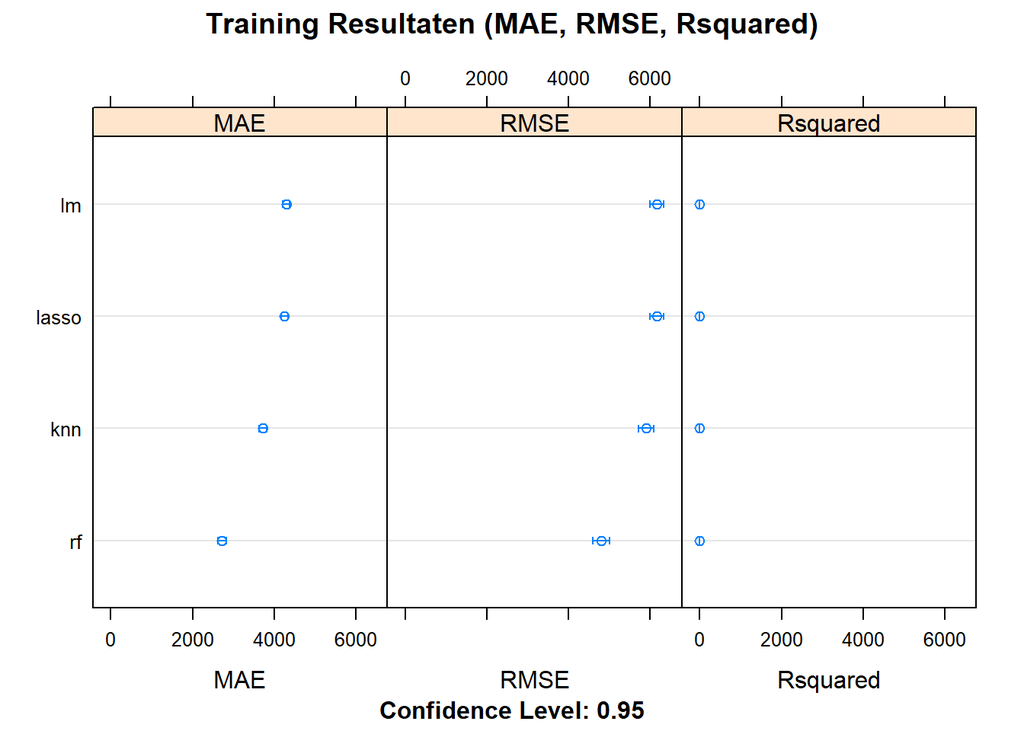

```r
dotplot(resultaat, main = "Training Resultaten (MAE, RMSE, Rsquared)")
```

Machine learning algoritmes:

- Lineaire regressie
- Lasso regressie
- Random forest regressie
- Knn regressie